# GWAS Diagnostics

## 1. Input data survey

The GWAS diagnose was conducted based on 27.243 observations (which is the number of common samples for response variable and covariates, see Venn diagram below).

### 1.1. Venn diagram based on sample ID’s for phenotype, genotype, and covariates

The Venn diagram displays which samples are common to the response and predictor variables and the covariates.

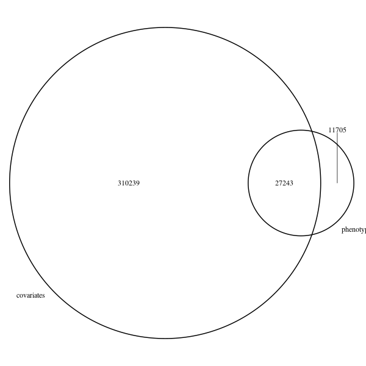

### 1.2. Heatmap for predictor and covariate correlations

The heatmap indicates the strength of the correlations between the independent variables (use the script *examine_covariates* to get detailed information).

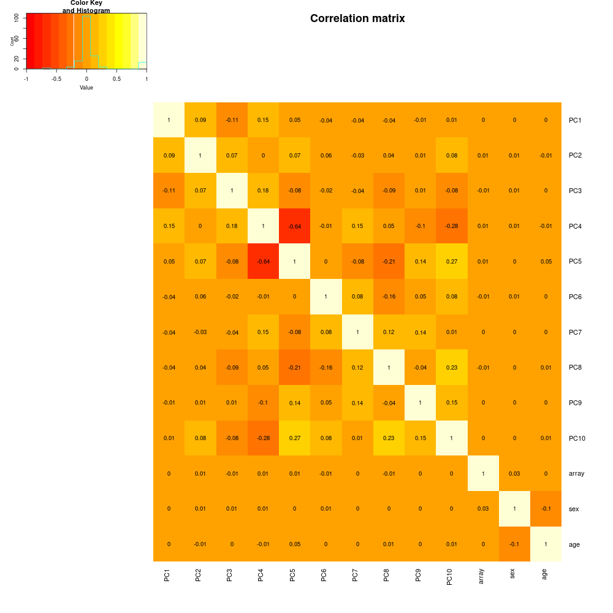

### 1.3. Variance inflation factors

Variance inflation factors (VIF) are calculated in order to discover multicollinearity. VIF can be obtained by regressing a single independent variable against all other independent variables. As a rule of thumb, no variance inflation factor should be bigger than 10. Otherwise, highly correlated variables should be removed from the model.

|  | vif | rating |
| --- | --- | --- |
| PC1 | 1.1095 | ok |
| PC2 | 1.0363 | ok |
| PC3 | 1.0838 | ok |
| PC4 | 1.9951 | ok |
| PC5 | 1.9808 | ok |
| PC6 | 1.0674 | ok |
| PC7 | 1.0911 | ok |
| PC8 | 1.2417 | ok |
| PC9 | 1.0669 | ok |
| PC10 | 1.2436 | ok |

[output cut: 3 more lines]

## 2. Linear Regression results obtained using `lm()` in **R**

### 2.1. Linear regression model:

liver_fat_a ~ PC1 + PC2 + PC3 + PC4 + PC5 + PC6 + PC7 + PC8 + PC9 + PC10 + array + sex + age

### 2.3. Some metrics obtained using `lm()`:

- **sigma** is the estimatimated standard deviation of the noise term
- **Fstat** is the value of the F-statistic
- **Rsquared** is coefficient of determination
- **Rsq.adj** is coefficient of determination adjusted for the number of predictors
- **CI_low** is the lower limit of the confidence interval for $\beta$
- **CI_up** is the upper limit of the confidence interval for $\beta$
- **AIC** is the Akaike information criterion (which estimates the quality of a gregession model, relative to others)

| sigma | Fstat | Rsquared | Rsq.adj | AIC |
| --- | --- | --- | --- | --- |
| 4.216 | 41.62 | 0.01948 | 0.01901 | 78410 |

### 2.4. Regression coefficients obtained with `lm()`:

|  | Estimate | Std. Error | t value | Pr(>\|t\|) |
| --- | --- | --- | --- | --- |
| (Intercept) | 4.33 | 0.3 | 14.4 | 7.32e-47 |
| PC1 | 0.0106 | 0.0167 | 0.635 | 0.525 |
| PC2 | 0.01 | 0.0173 | 0.58 | 0.562 |
| PC3 | 0.0258 | 0.0168 | 1.53 | 0.125 |
| PC4 | 0.0385 | 0.0125 | 3.08 | 0.00207 |
| PC5 | 0.00309 | 0.00554 | 0.557 | 0.577 |
| PC6 | 0.0106 | 0.0158 | 0.667 | 0.505 |
| PC7 | 0.0298 | 0.0143 | 2.08 | 0.0372 |
| PC8 | -0.00494 | 0.0141 | -0.35 | 0.727 |
| PC9 | -0.000897 | 0.00657 | -0.137 | 0.891 |

[output cut: 4 more lines]

## 3. Diagnostic plots regarding the residuals

### 3.1. Histogram for the magnitudes of the residuals

According to the linear model established, the residuals should be normally distributed. Consequently, the histogram below should approximately resemble a normal distribution. The residuals have been saved to diagnose_residuals_nomarker.RData .

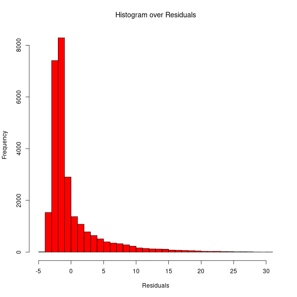

### 3.2. Plot of the residuals vs. the fitted values

This plot shows if residuals have non-linear patterns (which should **not** be the case). It is desirable that the residuals are equally spread around the horizontal line without distinct patterns. The p-value for the Non-constant Variance Score Test (**ncvTest** in **R**) is 4,57284e-37.

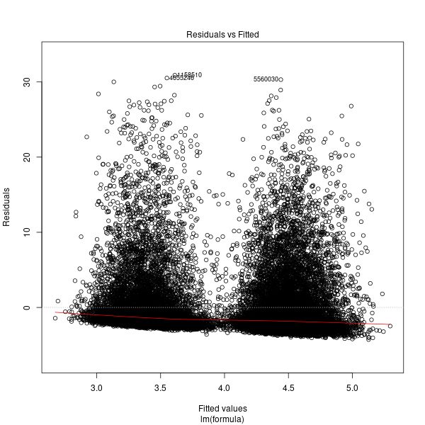

### 3.3. Normal Q-Q plot of the residuals

This plot shows if residuals are normally distributed. It is desirable that the points displaying the residuals are located close to the straight line.

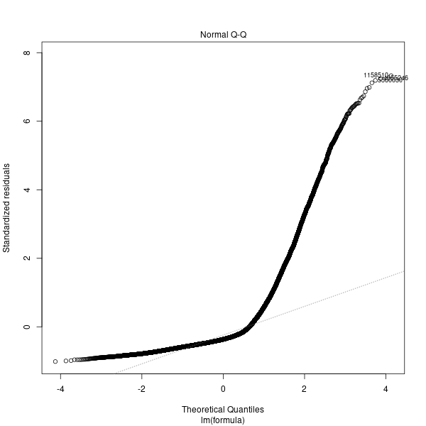

### 3.4. Scale-Location plot

The plot shows if residuals are spread equally along the ranges of predictors, allowing to check the equal variance (**homoscedasticity**) assumption. It is desirable that we see a horizontal line with equally (randomly) spread points.

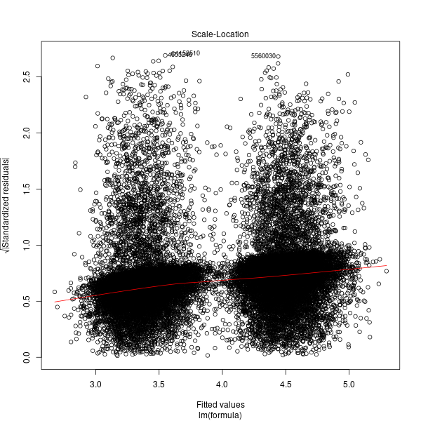

### 3.5. Autocorrelation of the residuals

The residuals should be independent according to the assumptions of the linear model applied. This means that the autocorrelation for any lag should be small. It is therefore desirable that all vertical lines standing for the magnitudes of autocorrelation are well inside the blue dashed lines displayed in the plot. The p-value for the **Durbin-Watson-Test** is 0,006

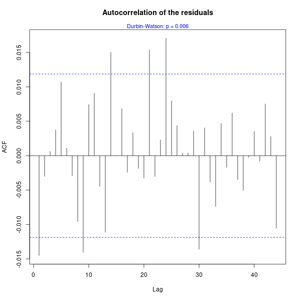

## 4. Influential observations and outliers

### 4.1. Cook’s distance

Cook’s distance quantifies the influence of each observation on the regression results. Cook’s distance is inferred by recalculating the regression results after removal of a single observation from the input dataset. It summarizes how much the results are changed when the observation is removed.

| id | Cook.D |
| --- | --- |
| 1647160 | 0.009847 |
| 5474398 | 0.003387 |
| 5018641 | 0.003025 |
| 5686058 | 0.002784 |
| 5954145 | 0.002783 |
| 4655246 | 0.002607 |

The cutoff for Cook’s distance is 0.9492353 (calculated as the median of the F-distribution for 13 and 27230 degrees of freedom). According to this cutoff, we have 0 variables being influental.

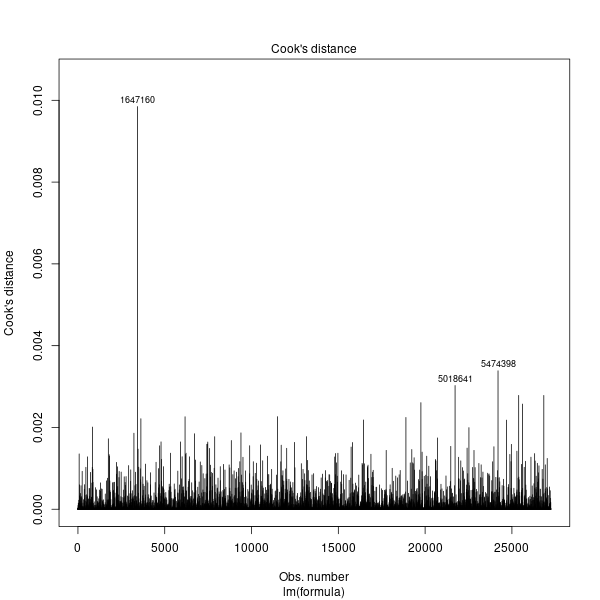

### 4.2. Plot of the residuals vs. leverage

The plot supports identification of influential observations. Influential observations are located at the upper right or the lower right corner of this plot. Cases outside the dashed line (Cook’s distance) might be influential to the regression results. i.e. the regression results will be altered if these observations are excluded from the model. ( Note that the dashed line indicating Cook’s distance may not be visible in the plot if all observations have a magninude of Cook’s D which is below the cutoff.)

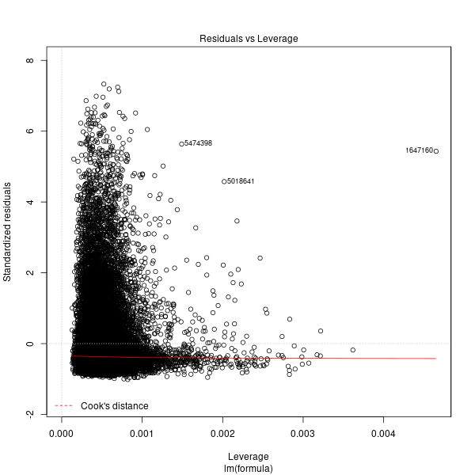

### 4.3. Outlier Test

Outliers were calculated using the function **outlierTest** in **R**. The number of hypothetical outliers obtained by this function was 166.

| id | rstudent | p.bonf |
| --- | --- | --- |
| 1158510 | 7.34 | 6.13e-09 |
| 4655246 | 7.25 | 1.18e-08 |
| 5560030 | 7.2 | 1.72e-08 |
| 5722736 | 7.13 | 2.85e-08 |
| 5141124 | 6.99 | 7.58e-08 |
| 2481699 | 6.97 | 9.12e-08 |
| 5222837 | 6.87 | 1.82e-07 |
| 2259398 | 6.74 | 4.26e-07 |
| 3447356 | 6.71 | 5.59e-07 |
| 4719098 | 6.68 | 6.58e-07 |

[output cut: 156 more lines]

## 5. Inverse response plot

The inverse response plot displays the response variable (i.e. the phenotype) on the x-axis and the fitted values on the y-axis. A relationship bettween these variables in the form $Y_{fitted} = \beta_0 + \beta_1 \cdot Y_{response}^\lambda$ is fitted by using the **nls** function in **R**. The estimated $\lambda$ for the model considered here is -1,07727

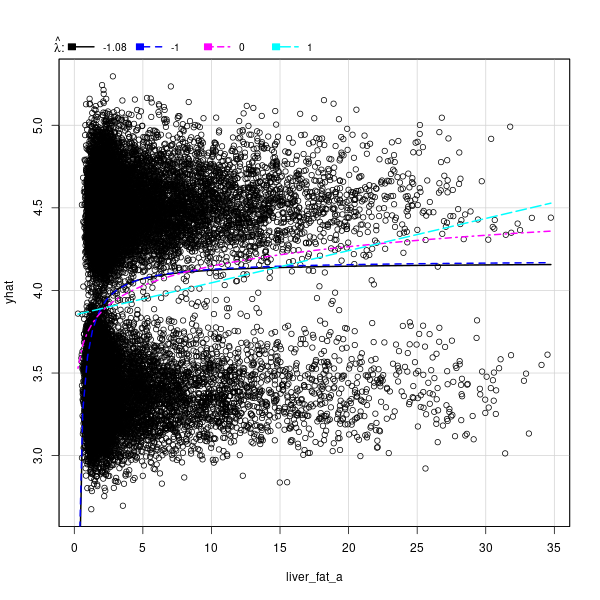

## 7. Technical information

- GWAS workfolder: /castor/project/proj/GWAS_DEV3/liver10